# COPD Modeling Pipeline (Logistic Regression and Bayesian Networks using ADASYN data)

Sia Hwang

2025-11-03

# Overview

This report describes the COPD prediction pipeline that combines:

- ADASYN-based oversampling for class imbalance handling
- Logistic Regression (LR) for feature significance
- Bayesian Network (BN) models:
  - BN-B (Blacklist-based)
  - BN-WB (Whitelist-based)
- MAP Imputation for missing values
- Bootstrap-based stability analysis for network robustness

# Step 1: Load and Inspect Data

Load the ADASYN-oversampled dataset and inspect its structure and target distribution.

```r
# Load the pre-processed and oversampled data
adasyn_data <- read.csv("/Users/hwangsia/adasyn_data_decoded.csv")

# Display the structure of the data
str(adasyn_data)
```

```
## 'data.frame':    3889 obs. of  10 variables:
##  $ age           : chr  "60s" "50s" "60s" "50s" ...
##  $ sex           : chr  "Male" "Male" "Male" "Female" ...
##  $ OccupationRisk: chr  "Non–at-risk" "At-risk" "Non–at-risk" "Non–at-risk" ...
##  $ Income        : chr  "High" "Low" "High" "High" ...
##  $ smoking       : chr  "Former Smoker" "Former Smoker" "Former Smoker" "Non-smoker" ...
##  $ Packyears     : chr  "low" "low" "low" "nan" ...
##  $ Asthma        : chr  "No" "No" "No" "No" ...
##  $ BMI_Group     : chr  "Obese" "Normal" "Obese" "Obese" ...
##  $ PM25_Group    : chr  "high" "low" "high" "high" ...
##  $ COPD          : int  0 0 1 0 0 0 0 0 0 0 ...
```

```r
# Check the distribution of the target variable (COPD)
table(adasyn_data$COPD)
```

```
##
##    0    1
## 1946 1943
```

# Step 2: Clean Missing Values

Convert custom missing tokens (e.g., “nan”, “NA”, ““) into standard R `NA` values and ensure all variables are treated as factors for categorical analysis.

```r
# Define a list of strings that represent missing values
missing_tokens <- c("nan", "NaN", "NA", "", "NAN", "Nan")

for (v in names(adasyn_data)) {
  # Convert column to character to handle mixed types
  col_chr <- as.character(adasyn_data[[v]])
  # Replace missing tokens with standard NA
  col_chr[col_chr %in% missing_tokens] <- NA
  # Convert back to factor
  adasyn_data[[v]] <- as.factor(col_chr)
}

# Generate a report of missing values
missing_report <- data.frame(
  variable = names(adasyn_data),
  n_missing = sapply(adasyn_data, function(x) sum(is.na(x))),
  prop_missing = round(sapply(adasyn_data, function(x) mean(is.na(x))), 4)
)

# Print the missing value summary as a clean table
knitr::kable(missing_report, caption = "Missing Value Summary (Raw ADASYN Data)")
```

Missing Value Summary (Raw ADASYN Data)

|  | variable | n_missing | prop_missing |
| --- | --- | --- | --- |
| age | age | 0 | 0.0000 |
| sex | sex | 0 | 0.0000 |
| OccupationRisk | OccupationRisk | 0 | 0.0000 |
| Income | Income | 65 | 0.0167 |
| smoking | smoking | 0 | 0.0000 |
| Packyears | Packyears | 1951 | 0.5017 |
| Asthma | Asthma | 0 | 0.0000 |
| BMI_Group | BMI_Group | 12 | 0.0031 |
| PM25_Group | PM25_Group | 0 | 0.0000 |
| COPD | COPD | 0 | 0.0000 |

# Step 3: Mode Imputation (for Training)

BN structure learning algorithms require a complete dataset (no `NA` values). We create a training-specific dataset (`adasyn_data_clean`) by imputing `NA` values with the mode (most frequent category). This is done for predictors only.

```r
# Helper function to find the mode of a vector
get_mode <- function(v) {
  tab <- table(v, useNA = "no")
  names(tab)[which.max(tab)]
}

# Create a clean copy of the data for imputation
adasyn_data_clean <- adasyn_data

# Loop over predictors (all columns except COPD) and impute NAs
for (v in setdiff(names(adasyn_data_clean), "COPD")) {
  if (any(is.na(adasyn_data_clean[[v]]))) {
    m <- get_mode(adasyn_data_clean[[v]])
    adasyn_data_clean[[v]][is.na(adasyn_data_clean[[v]])] <- m
  }
}
```

# Step 4: Logistic Regression (Feature Significance)

Run a Logistic Regression model on the mode-imputed data to identify statistically significant predictors. This informs the `whitelist` for the BN-WB model.

```r
# Ensure all variables are factors for the GLM
lr_ready_data <- adasyn_data_clean %>%
  mutate(across(everything(), as.factor))

# Fit the GLM
fit_glm <- glm(
  COPD ~ age + sex + Income + OccupationRisk + Asthma +
    smoking + Packyears + BMI_Group + PM25_Group,
  data = lr_ready_data,
  family = binomial(link = "logit")
)

# Print the model summary (coefficients, p-values, etc.)
summary(fit_glm)
```

```
##
## Call:
## glm(formula = COPD ~ age + sex + Income + OccupationRisk + Asthma +
##     smoking + Packyears + BMI_Group + PM25_Group, family = binomial(link = "logit"),
##     data = lr_ready_data)
##
## Coefficients:
##                           Estimate Std. Error z value Pr(>|z|)
## (Intercept)               -0.17200    0.20386  -0.844 0.398843
## age60s                     0.55542    0.08238   6.742 1.56e-11 ***
## age70+                     1.04219    0.11260   9.255  < 2e-16 ***
## sexMale                    0.88034    0.11236   7.835 4.69e-15 ***
## IncomeLow                  0.25949    0.07818   3.319 0.000903 ***
## OccupationRiskNon–at-risk -0.11418    0.08634  -1.322 0.186022
## AsthmaYes                  1.79506    0.48329   3.714 0.000204 ***
## smokingFormer Smoker      -0.53007    0.10587  -5.007 5.53e-07 ***
## smokingNon-smoker         -0.85861    0.12816  -6.699 2.09e-11 ***
## Packyearslow              -0.19741    0.13538  -1.458 0.144804
## BMI_GroupObese            -0.30816    0.07177  -4.294 1.76e-05 ***
## PM25_Grouplow              0.27597    0.07168   3.850 0.000118 ***
## ---
## Signif. codes:  0 '***' 0.001 '**' 0.01 '*' 0.05 '.' 0.1 ' ' 1
##
## (Dispersion parameter for binomial family taken to be 1)
##
##     Null deviance: 5391.3  on 3888  degrees of freedom
## Residual deviance: 4756.2  on 3877  degrees of freedom
## AIC: 4780.2
##
## Number of Fisher Scoring iterations: 4
```

# Step 5: Bayesian Network (BN-B Model)

Create the first Bayesian Network model (BN-B), which relies only on a `blacklist` to constrain the structure learning.

## 5.1 Define Blacklist

Block edges that violate the pre-defined causal/temporal hierarchy (e.g., `COPD` cannot cause `age`).

```r
layer1 <- c("age","sex")
layer2 <- c("PM25_Group")
layer3 <- c("OccupationRisk","Income")
layer4 <- c("Asthma","BMI_Group","smoking","Packyears")
target <- c("COPD")

vars_all <- c(layer1, layer2, layer3, layer4, target)

# Helper function to create hierarchical blacklist
mk_layer_blacklist <- function(layers) {
  bl <- data.frame(from=character(), to=character())
  for (i in seq_along(layers)) {
    for (j in seq_len(i-1)) {
      bl <- rbind(bl, expand.grid(from = layers[[i]], to = layers[[j]]))
    }
  }
  bl
}

# Combine hierarchical blacklist with the rule that 'COPD' cannot be a parent
blacklist_BN_B <- rbind(
  mk_layer_blacklist(list(layer1, layer2, layer3, layer4, target)),
  expand.grid(from = target, to = setdiff(vars_all, target))
) %>% distinct()
```

## 5.2 Learn Structure & Parameters

Learn the BN-B structure using the `pc.stable` algorithm and fit parameters using Bayesian estimation.

```r
bn_B_structure <- pc.stable(
  adasyn_data_clean,
  blacklist = blacklist_BN_B,
  test = "mi" # Mutual Information test for categorical data
)

bn_B_fitted <- bn.fit(bn_B_structure, data = adasyn_data_clean, method = "bayes", iss = 1)
```

# Step 6: MAP Imputation (Helper Function)

Define the function for MAP (Maximum A Posteriori) imputation. This function uses a trained BN to infer the most probable value for a missing cell, considering the other variables in that row as evidence.

```r
# This helper function will be used later in the CV pipeline (not run here)
impute_one_cell_map <- function(row_values, target_var, bn_model, n_samples = 5000) {

  # Use all non-NA values as evidence, excluding the target variable itself
  ev_list <- as.list(row_values)
  ev_list[[target_var]] <- NULL
  ev_list <- ev_list[!is.na(ev_list)]

  # Use cpdist (Likelihood Weighting) to sample from the posterior distribution
  samp_df <- suppressWarnings(cpdist(
    bn_model, nodes = target_var, evidence = ev_list,
    method = "lw", n = n_samples
  ))

  # Return the mode (most frequent value) of the samples, which is the MAP estimate
  if (nrow(samp_df) == 0) return(NA_character_)
  tab <- table(samp_df[[target_var]], useNA = "no")
  names(tab)[which.max(tab)]
}
```

# Step 7: BN-B Bootstrap (1500 iterations)

Assess the structural stability of the BN-B model by learning 1500 networks on bootstrap resamples of the data. This provides confidence scores (`strength`) for each edge.

```r
set.seed(42)

boot_res <- boot.strength(
  data = adasyn_data_clean,
  R = 1500,
  algorithm = "pc.stable",
  algorithm.args = list(test = "mi", blacklist = blacklist_BN_B)
)

# Create the averaged network based on a strength threshold of 0.3
bn_B_avg <- averaged.network(boot_res, threshold = 0.3)
```

# Step 8: BN-WB Model (Whitelist + Blacklist)

Create the BN-WB model, which adds a `whitelist` to the BN-B constraints. The whitelist forces the inclusion of edges from statistically significant predictors (identified by LR in Step 4) to the `COPD` node.

```r
# Define the whitelist (all predictors except OccupationRisk and Packyears)
vars_to_force <- setdiff(vars_all, c(target, "OccupationRisk", "Packyears"))
whitelist_BN_WB <- expand.grid(from = vars_to_force, to = target)

# Learn the structure using both blacklist and whitelist
bn_WB_structure <- pc.stable(
  adasyn_data_clean,
  blacklist = blacklist_BN_B,
  whitelist = whitelist_BN_WB,
  test = "mi"
)

# Fit the parameters
bn_WB_fitted <- bn.fit(bn_WB_structure, data = adasyn_data_clean, method = "bayes", iss = 1)
```

# Step 9: BN-WB Bootstrap and Stability Analysis

Assess the structural stability of the BN-WB model using the same 1500-iteration bootstrap approach.

```r
set.seed(42)

boot_res_WB <- boot.strength(
  data = adasyn_data_clean,
  R = 1500,
  algorithm = "pc.stable",
  algorithm.args = list(
    test = "mi",
    blacklist = blacklist_BN_B,
    whitelist = whitelist_BN_WB
  )
)

# Create the averaged network
bn_WB_avg <- averaged.network(boot_res_WB, threshold = 0.3)
```

# Step 10: Visualization

Plot the final, averaged network structures for both BN-B and BN-WB. These graphs represent the stable, consensus relationships found during bootstrapping.

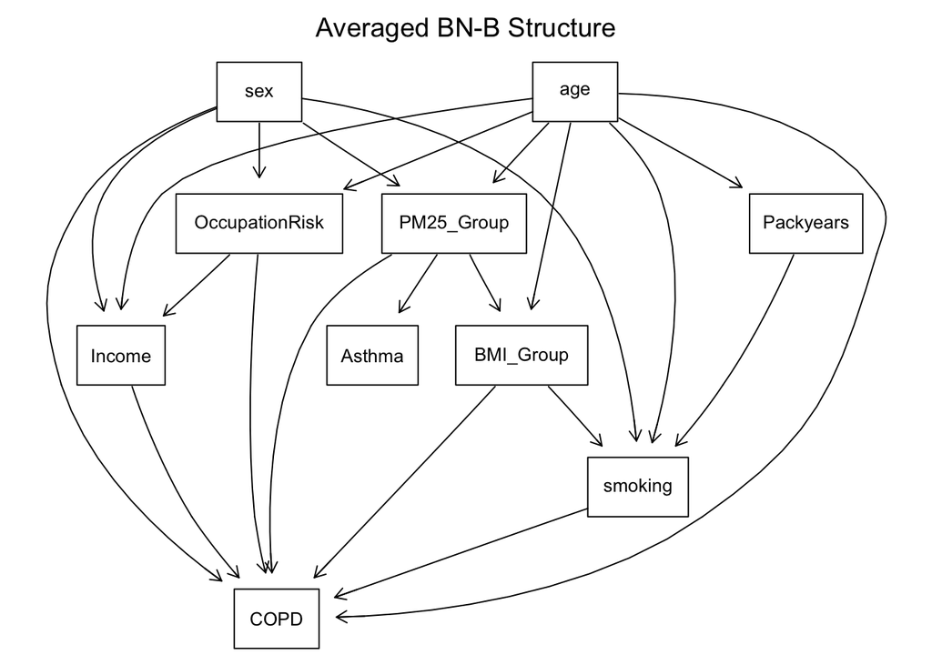

```r
# Plot the averaged BN-B structure
graphviz.plot(bn_B_avg, layout = "dot", main = "Averaged BN-B Structure")
```

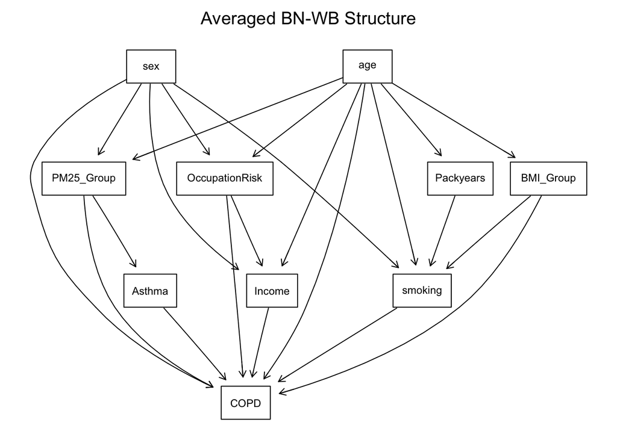

```r
# Plot the averaged BN-WB structure
graphviz.plot(bn_WB_avg, layout = "dot", main = "Averaged BN-WB Structure")
```

# Summary

- ADASYN balanced the minority COPD class.
- Mode imputation ensured no missing values for BN training.
- BN-B captured unconstrained relationships based on data and blacklist.
- BN-WB incorporated domain-informed links from LR analysis.
- Bootstrap averaging enhanced structural robustness for final interpretation.